# Dados de opiniões sobre filmes

## Sobre os dados

Para essa parte do problema usaremos dados sobre avaliações de filmes feita por pessoa de todo o mundo em um forum online. Cada filme pode receber notas entre 1-5 e possui n generos distintos.

## O que fazer

Temos duas perguntas para ser respondidas em nossa pesquisa.

1. Escolha uma trilogia (ou uma n-logia com n > 3) e avalie para qual dos episódios da trilogia é melhor avaliação e qual episódio possui mais variação nas notas atribuídas ao filme.
2. Normalmente os filmes têm vários gêneros. Existe uma relação entre em quantos gêneros os filmes se encaixam e a avaliação que os filmes recebem? Mais especificamente: se consideramos a os filmes com 1, 2, 3, …, n gêneros, existe alguma quantidade de gêneros num mesmo filme que em geral recebe avaliações melhores? Caso exista, estime a diferença entre essa combinação e filmes com apenas um gênero.

## Analise

Os filmes escolhidos para a analise da primeira pergunta foi a trilogia original do Exterminator do futuro (Terminator) 1, 2 e 3 de 1984, 1991 e 2003 respectivamente, com um nível de confiança de 95%.

1.1. Observando a média das notas que foram atribuidas aos três filmes, não podemos concluir que o Exterminador no Futuro 1 foi melhor avaliado do que o Exterminador no Futuro 2 e vise-versa. Mas podemos inferir, com base nos dados estudados, que o Exterminador no Futuro 3 é o pior avaliado, conforme gráfico abaixo:

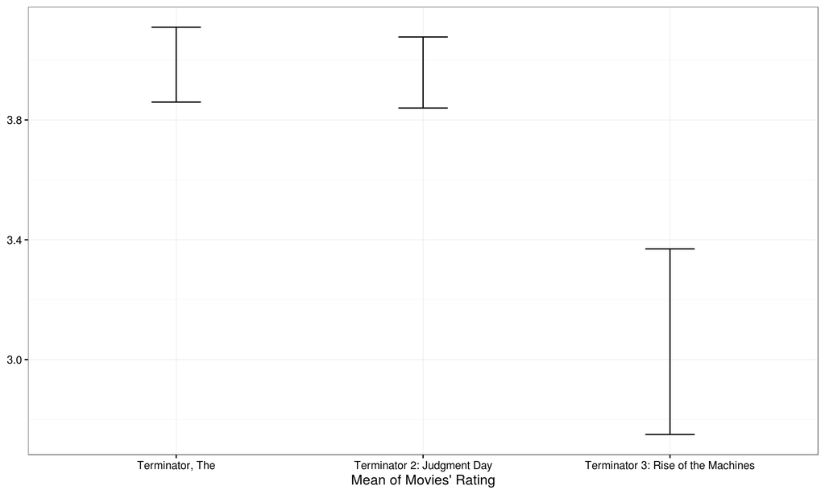

1.2. Observando o desvio padrão das notas que foram atribuidas aos três filmes, mas não podemos concluir que exista uma variação significativa entre os filmes, conforme gráfico abaixo:

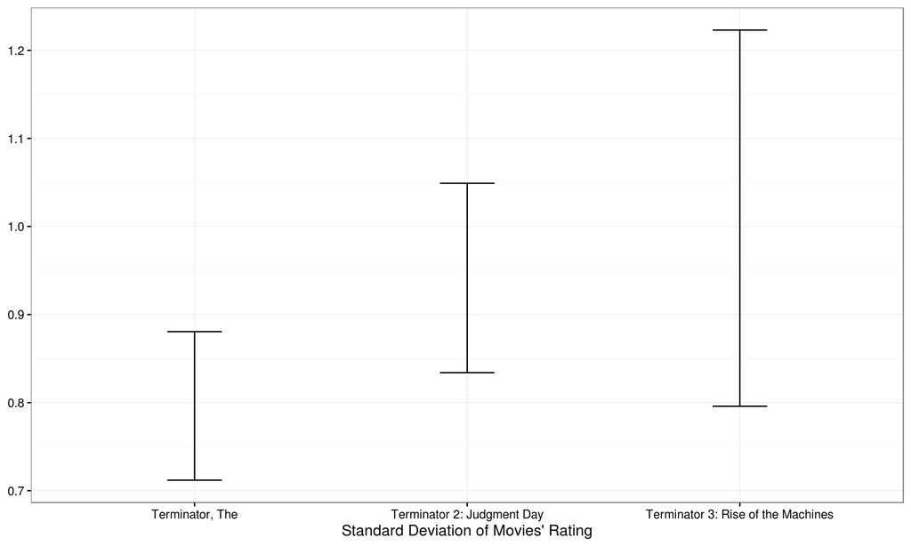

2.1 Observando a média das notas que foram atribuidas aos filmes, podemos concluir que os filmes com apenas 1 gênero são os que recebem as piores avaliação e os filmes com 7 gêneros diferentes são os que recebem as melhores avaliações. Já em relação os demais filmes não podemos concluir nada sobre a existência de uma correlação entre suas avaliações e a quantidade de gêneros, conforme gráfico abaixo:

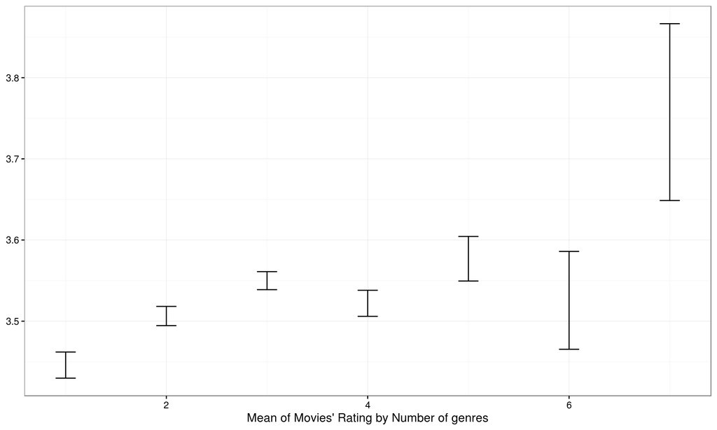

2.2 Analisando o gráfico abaixo, podemos afirma que realmente existe um diferenca entre as notas a atribuidas aos filmes com 1 e 7 gêneros, pois o intervalor de *Diff 1-7* não contém o zero.

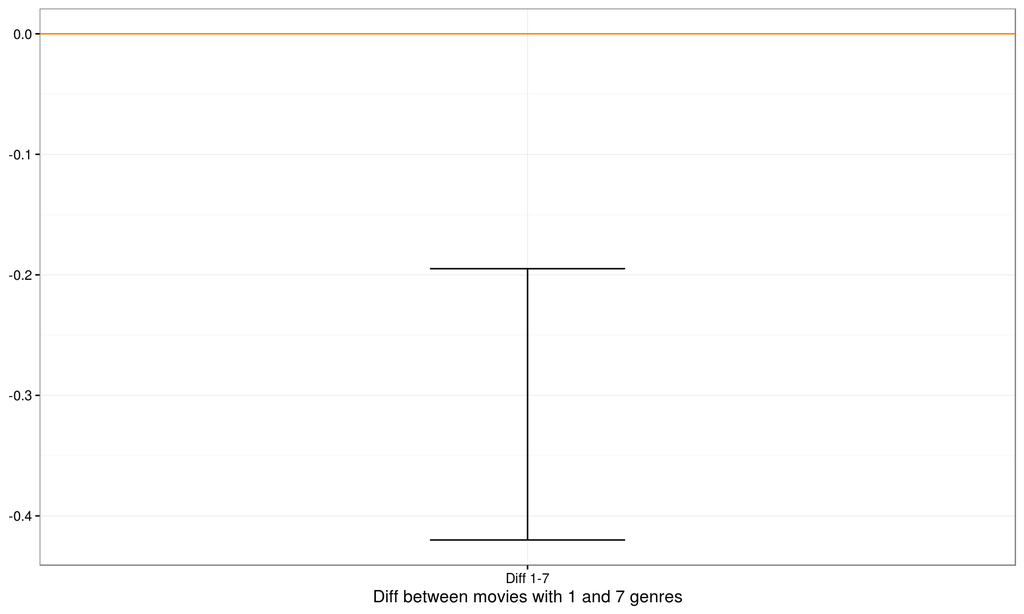